# American Journal of Botany

[American Journal of Botany](https://bsapubs.onlinelibrary.wiley.com/journal/15372197)

[Volume 98, Issue 3](https://bsapubs.onlinelibrary.wiley.com/toc/15372197/2011/98/3) p. 426-438

[figure not shown]

Special Paper

Free Access

# The Fungi: 1, 2, 3 … 5.1 million species?†

[Meredith Blackwell](https://bsapubs.onlinelibrary.wiley.com/authored-by/ContribAuthorRaw/Blackwell/Meredith),

First published: 01 March 2011

https://doi.org/10.3732/ajb.1000298

Citations: 867

†

The author thanks N. H. Nguyen, H. Raja, and J. A. Robertson for permission to use their photographs, two anonymous reviewers who helped to improve the manuscript, and David Hibbett, who graciously provided an unpublished manuscript. She acknowledges funding from NSF DEB-0417180 and NSF-0639214.

## Abstract

• *Premise of the study:* Fungi are major decomposers in certain ecosystems and essential associates of many organisms. They provide enzymes and drugs and serve as experimental organisms. In 1991, a landmark paper estimated that there are 1.5 million fungi on the Earth. Because only 70000 fungi had been described at that time, the estimate has been the impetus to search for previously unknown fungi. Fungal habitats include soil, water, and organisms that may harbor large numbers of understudied fungi, estimated to outnumber plants by at least 6 to 1. More recent estimates based on high-throughput sequencing methods suggest that as many as 5.1 million fungal species exist.

• *Methods:* Technological advances make it possible to apply molecular methods to develop a stable classification and to discover and identify fungal taxa.

• *Key results:* Molecular methods have dramatically increased our knowledge of Fungi in less than 20 years, revealing a monophyletic kingdom and increased diversity among early-diverging lineages. Mycologists are making significant advances in species discovery, but many fungi remain to be discovered.

## What are Fungi?

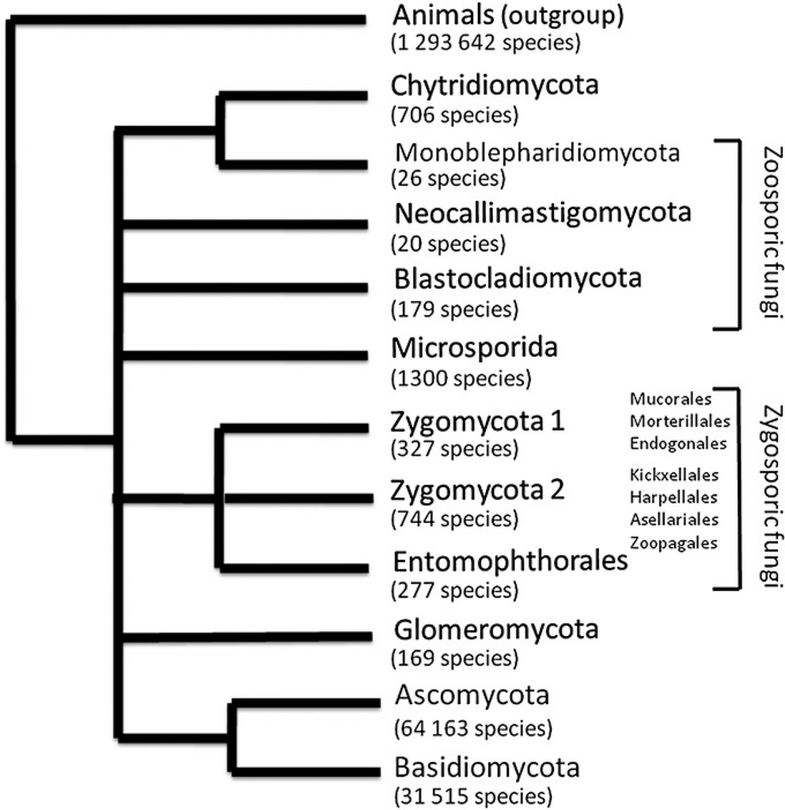

**Figure 1**

Fungal phyla and approximate number of species in each group (84). Evidence from gene order conversion and multilocus sequencing indicates that microsporidians are Fungi (see below; 95). Note also that zoosporic and zygosporic fungal groups are not supported as monophyletic. Tree based on 68, 170, and 76.

Most fungi lack flagella and have filamentous bodies with distinctive cell wall carbohydrates and haploid thalli as a result of zygotic meiosis. They interact with all major groups of organisms. By their descent from an ancestor shared with animals about a billion years ago plus or minus 500 million years (21), the Fungi constitute a major eukaryotic lineage equal in numbers to animals and exceeding plants (Figs. 2–10). The group includes molds, yeasts, mushrooms, polypores, plant parasitic rusts and smuts, and *Penicillium chrysogenum*, *Neurospora crassa*, *Saccharomyces cerevisiae*, and *Schizosaccharomyces pombe*, the important model organisms studied by Nobel laureates.

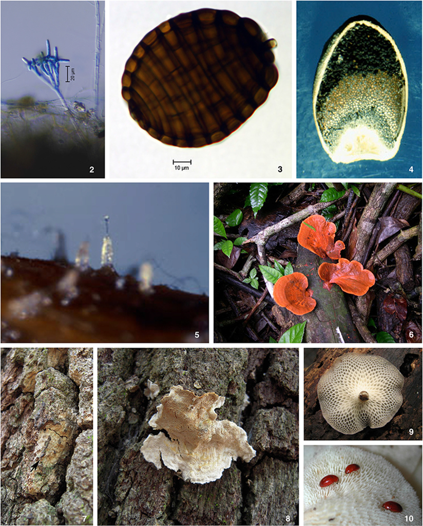

**Figure 2–10**

Examples of fungal diversity. **2.** *Lemonniera* sp. Tetraradiate conidia developed on a submerged leaf in a well-aerated freshwater stream surrounded by lush vegetation. This type of aquatic species, an Ingoldian ascomycete, is named for C. T. Ingold, who pioneered the study of these fungi, that are characterized by highly branched conidia. Photo courtesy of H. Raja. **3.** The aero-aquatic ascomycete *Helicoon gigantisporum* produces distinctive tightly coiled conidia. As the spore develops air is trapped in the coil and causes it to be buoyant. This feature is an adaptation for the polyphyletic aero-aquatic fungi that grow on leaves in slow-moving or stagnant freshwater. Photo courtesy of H. Raja. **4.** The smut *Testicularia* sp. develops in the ovary of grasses and (as shown here) sedges. The spores mature sequentially, with the dark spores being more mature. A plant taxonomy student once thought he had discovered a new species of *Leersia*, distinguished by large ovaries of ca. 1 cm, only to be disappointed that the enlargement was caused by a fungus. It is helpful to mycologists when plant taxonomists collect and accession fungal diversity by selecting some diseased plant specimens, an activity that should be encouraged. **5.** Perithecia of *Pyxidiophora* sp. (Laboulbeniomycetes) developed in moist chamber on moose dung from Meredith Station, New Brunswick, Canada. The 150 µm long ascospores are seen at the tip of the perithecium neck in the center. Spores adhere to phoretic mites that are carried by dung beetles to fresh dung piles. Some fungi have complex animal dispersal systems. *Pyxidiophora* species are usually mycoparasites that grow on fungi in dung or other substrates including wrack washed up on beaches. The genus is a “missing link” and provided clues to confirm that Laboulbeniomycetes are ascomycetes and not other kinds of fungi or floridian red algae. **6.** The ca. 8 cm wide basidiomata of *Pycnoporus* sp., a wide-ranging, brightly colored, wood-decaying polypore, photographed at Barro Colorado Island, Panama. Some collectors have referred to basidiomycetes that produce colorful basidiomata as charismatic megamycota of the fungus world. **7.** *Peniophorella baculorubrensis*, a bark-decaying basidiomycete common on and restricted to living live oak (*Quercus virginiana*), decays the bark and changes its water-holding capacity. The effect of decay on bryophyte communties by this fungus was first studied by ecologists (118) more than 70 yr ago but was not described until a specialist on wood-decaying fungi happened to notice it on the Louisiana State University campus, Baton Rouge (57). The inconspicuous basidiomata are shown growing on the lower side of a 7 cm long bark segment aimed downward for basidiospore discharge in response to gravity. **8.** Basidiomata of *Perenniporia phloiophila* on the bark of living *Quercus virginiana*. Although the basidiomata are obvious against the darker bark, this species was not described until it was discovered at the same time and often on the same trees as *Peniophorella baculorubrensis*. Although the fungus usually rots only the outer bark, it will invade and decay wood whenever the vascular cambium is broached by a bird or insect. In addition to the two species on live oak, six other species have been described from the campus, illustrating the need for specialists to study noncharismatic fungi. **9.** A basidioma (8 cm diameter) of the wood-decaying fungus, *Favolus tenuiculus*, a favorite food of several species of mushroom-feeding beetles (see Fig. 10). Photo courtesy of N. H. Nguyen. **10.** The small (>10 mm long) brightly colored beetle, *Mycotretus* sp. (Erotylidae), was collected at Barro Colorado Island, Panama. Many erotylid beetles have specialized yeast-packed pouches at the anterior end of the midgut. More than 200 novel yeasts have been isolated from the gut of ca. 15 families of mushroom-feeding beetles (151). Photo courtesy of James A. Robertson.

Phylogenetic studies provided evidence that nucleriid protists are the sister group of Fungi (103), nonphotosynthetic heterokont flagellates are placed among brown algae and other stramenopiles, and slime mold groups are excluded from Fungi (4). Current phylogenetic evidence suggests that the flagellum may have been lost several times among the early-diverging fungi and that there is more diversity among early diverging zoosporic and zygosporic lineages than previously realized (29; 26; 68; 146).

Sequences of one or several genes are no longer evidence enough in phylogenetic research. A much-cited example of the kind of problem that may occur when single genes with different rates of change are used in analyses involves Microsporidia. These organisms were misinterpreted as early-diverging eukaryotes in the tree of life based on their apparent reduced morphology (34). Subsequently, phylogenetic analyses using small subunit ribosomal RNA genes wrongly supported a microsporidian divergence before the origin of mitochondria in eukaryotic organisms (163). More recent morphological and physiological studies have not upheld this placement, and analyses of additional sequences, including those of protein-coding genes, support the view that these obligate intracellular parasites of insect and vertebrate hosts are members of the Fungi (81; 38). Additional evidence from genome structure as well as phylogenetic analyses, supports the inclusion of microsporidians within the Fungi and indicates that comparison of whole genomes contributes to the solution of challenging phylogenetic problems (95).

The level of resolution and sophistication of systematics studies made possible by molecular markers and phylogenetic analyses put mycologists on equal footing with other biologists for competitive funding, and they joined in several community-wide efforts to organize fungal diversity within a phylogenetic classification. Three projects funded by the National Science Foundation were initiated, including the Research Coordination Network: A Phylogeny for Kingdom Fungi (Deep Hypha) and successive Tree of Life projects, Assembling the Fungal Tree of Life (AFTOL-1) and a second ongoing project (AFTOL-2) (26). A major product of the Deep Hypha project was the publication of 24 papers on fungal phylogeny in a single journal issue (*Mycologia* 98: 829–1103). The papers included an introduction to progress in fungal phylogeny, a paper on dating the origin of Fungi, one on the evolution of morphological traits, and 21 articles with multilocus phylogenies of most major groups. Participants included 156 authors with some involved in more than one paper; only 72 of the authors were originally from North America. The multi-investigator AFTOL-1 publication (68) included a widely used and often cited phylogenetic classification to the level of order (e.g., 84; The NCBI Entrez Taxonomy Homepage, http://www.ncbi.nlm.nih.gov/taxonomy; Science Watch, http://sciencewatch.com/dr/nhp/2009/09jannhp/09jannhpHibb). The paper included 68 authors from more than 20 countries. It is important to note that there was broad participation and, essentially, global involvement on these projects, emphasizing that studies of biodiversity are indeed global endeavors. Additional pages were contributed to the Tree of Life web project (http://www.tolweb.org/Fungi/2377) to make information on fungi more accessible to students and the general public. Two objectives of the ongoing AFTOL-2 project include increased taxon sampling of fungi for molecular data and the discovery of correlated morphological and biochemical characters (AFTOL Structural and Biochemical Database, https://aftol.umn.edu; 35).

## Known fungal species

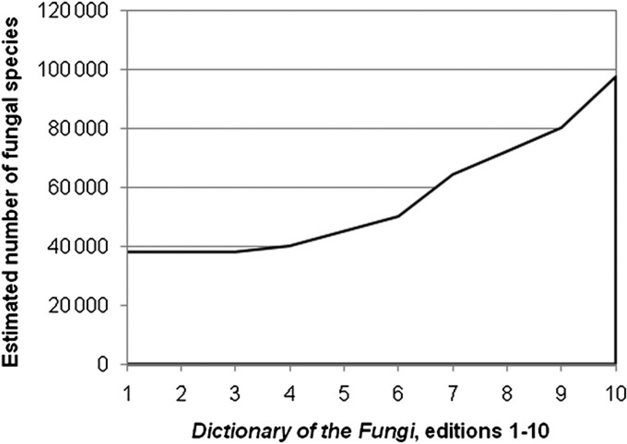

**Figure 11**

## Estimated total fungal numbers

In 1991, a landmark paper provided several qualified estimates of the number of fungi on the Earth based on ratios of known fungi to plant species in regions where fungi were considered to be well-studied (64). “Estimate G” of 1.5 million species was accepted as a reasonable working hypothesis based on a fungus to plant ratio of 6:1, in contrast to the much lower 50–60-yr-old estimates by 25 of 100000 fungal species and by 102 of 250000 species based on one fungus for every phanerogam known at the time. A more recent estimate of the total number of fungi, 720256 (138), is also low compared to present estimates that include environmental samples.

64 estimate now is considered to be conservative by many, including Hawksworth (66), because numerous potential fungal habitats and localities remain understudied (65). Furthermore, the use of molecular methods had not yet been considered as a means of species discovery. For example, analysis of environmental DNA samples from a soil community revealed a high rate of new species accumulation at the site, and these data supported an estimate of 3.5 to 5.1 million species (114). Using the present discovery rate of about 1200 fungal species per year based on the last 10 years, Hibbett and his colleagues (in press) estimated that it would take 1170 years to describe 1.4 million fungi (based on Estimate G of 64) and 2840 to 4170 yr to describe 3.5 to 5.1 million (based on 114).

## How to discover new fungi

Collecting and culturing fungi from the environment will remain important because of the need to identify specimens, revise taxonomy, assess the roles in the environment, and provide strains for biological control, environmental remediation, and industrial processes. A physical specimen, including an inert culture, is still required as a type specimen (but see Conclusions later), and vouchers of known fungi are used for documenting DNA sequences deposited in some databases (113). For example, the current AFTOL project has a requirement that each sequence deposited as part of the project be linked to a specimen, including a culture.

All taxa biological inventories (ATBIs) attempt to survey organisms within particular geographical regions by collection of specimens and culture of substrates. One of these, Discover Life in America, All Taxa Biological Inventory, seeks to survey an estimated 50000 to 100000 species of organisms in the Great Smoky Mountains National Park. Karen Hughes and Ronald Petersen have been successful in collecting more than 3000 species of fungi, mostly agarics housed in the University of Tennessee Fungal Herbarium (http://tenn.bio.utk.edu/fungus/database/fungus-browse-results.asp?GSMNP=GSMNP), out of about 17000 species of all taxa that have been collected by others in the park (Biodiversity Surveys and Inventories: Agaric Diversity in the Great Smoky Mountains National Park, NSF DEB 0338699). All fungal specimens have been identified, and the agarics have been studied to the extent that a culture, ITS barcode sequence, and genetic analysis are available for many species. This successful project has required hours of time over a number of years and costly resources for studying the material, but it serves as an example of the commitment needed to acquire specimen-based information on fungi.

DNA methodology makes it possible to use independent sampling methods to discover the presence of organisms without ever seeing a culture or a specimen. Several new methods significantly outperform previous automated sequencing methods (e.g., 80; 104). Although there may be certain limitations and biases for the different methods (6; 155), mycologists have been quick to embrace them in ecological and biodiversity studies. 114 pointed out that collection and culture methods revealed numbers of fungi similar to those acquired by sampling environmental DNA. 69, however, used data from GenBank to show that by 2008 and 2009 the number of environmental samples, excluding overwhelming numbers of sequences discovered by pyrosequencing, exceeded the accessions of specimen-based sequences. The rapid development of automated, high-throughput methods also has made it possible to acquire whole genome sequences for population level studies (97; 112).

## Which regions of the Earth harbor fungal diversity?

Fungi grow in almost all habitats on Earth, surpassed only by bacteria in their ability to withstand extremes in temperature, water activity, and carbon source (129). Tropical regions of the world are considered to have the highest diversity for most groups of organisms (122; 70), and this is generally true for fungi as well (10).

A group of researchers are studying the diversity of the Guyana Shield. For the last 11 years, Terry Henkel and Cathie Aime and their colleagues have studied the fungi in six 1-km<sup>2</sup> plots—three in a *Dicymbe corymbosa*-dominated forest and three in a mixed tropical forest. Their current collections contain 1200 morphospecies, primarily basidiomycetes. Approximately 260 species were collected repeatedly only in the *Dicymbe* plots. Thus far, two new genera and ca. 50 new species have been described. On the basis of groups already studied, Aime estimated that ca. 120 new ectomycorrhizal taxa have been discovered. Including novel saprobes as well as ectomycorrhizal fungi, ca. 500 new species are expected among the 1200 taxa collected. It is clear, however, that these are not simply high numbers of new taxa, but biologically interesting fungi as well (2). One species is so unusual, that a reviewer of the original report called it “the find of the century” (130). As Aime has quipped “if one were to compare the ratio of fungi to plants in the *Dicymbe* plots as did 64, the ratio would be 260 to 1, obviously an overestimate but also a cautionary exercise in basing any estimate on a single ecotype” (M. C. Aime, Louisiana State University, personal communication, August 2010).

Many fungi have in fact come from temperate regions, and some studies report a high diversity of fungi. For example, in a study of indoor air from buildings using culture-independent sampling methods, diversity was found to be significantly higher in temperate sites independent of building design or use. The authors also alluded to the possibility that previous studies of certain mycorrhizal fungi showed similar trends (7). More investigation in this area is needed, but it is clear that many undescribed fungi are present in temperate regions. Popular literature often rationalizes the need to save the rainforests, not because of their intrinsic value, but because of the potential drug-producing organisms that may be found there. Many of the commercially most successful fungal drugs, however, come from temperate fungi. *Penicillium chrysogenum*, producer of penicillin, was found in a northern temperate city. Another remarkable fungus, *Tolypocladium inflatum* from Norwegian soil, synthesizes cyclosporine, an immune-suppressant drug that revolutionized organ transplants (28); the sexual state of this fungus was collected in New York, USA (71). Today the drug is commonly used to treat dry eye (119), as well as many serious conditions. Statins produced by fungi such as *Aspergillus terreus* from temperate regions, combat high cholesterol levels, as well as providing other benefits (159; 14; 15).

In temperate deserts, mycorrhizal boletes, agarics, and rust and smut fungi, are common. A surprising number of wood-decaying basidiomycetes have been discovered on living and dead desert plants, including cacti and are in the University of Arizona, Robert L. Gilbertson Mycological Herbarium (http://ag.arizona.edu/mycoherb/herbholdings). When a noted mycologist moved to Arizona early in his career, he became excited about the new and unreported fungal diversity found in the desert. His proposed study of the wood-decaying fungi of the Sonoran Desert was poorly received with a comment that wood-decaying fungi were not present in the desert (R. L. Gilbertson, University of Arizona, personal communication, August 1979). The Sonoran Desert, however, has many plants (e.g., cacti, ocotillo, and mesquite and other desert legumes) that are substrates for polypores and resupinate basidiomycetes (e.g., 58, 59).

Fungi also grow at low temperatures. An example involves fungal deterioration of historic huts built between 1901 and 1911 for use by Antarctic explorers including Robert Scott and Ernest Shackleton, and although there are not large species numbers, it is important not to overlook this fungal habitat in diversity studies (67). Lichens have often been reported to be common in Arctic and Antarctic regions (172), and yeasts are active under frozen conditions in the Antarctic (162; 5). In some cases, a yeast isolated from the Antarctic (based on 28S rDNA barcoding) also has been reported from varied habitats, including human infections, the gut of insects, deep seas, and hydrocarbon seeps (90; 18; personal observation). Although some fungi are specialized for cold regions, others simply occupy a wide variety of environmental conditions.

Many regions and habitats of the world need to be included in fungal discovery. In general, microscopic fungi and those that cannot be cultured are very poorly known. Parts of Africa remain to be collected for many, although not all, fungal groups (39). Fungi are important as symbionts, and they are associated with every major group of organisms, bacteria, plants and green algae, and animals including insects. Because certain under-studied symbiotic associations are known to include large numbers of fungi, these are a good place to search for new taxa. The associated organisms also allow for resampling, a quick way to obtain data about host specificity. Targeting hosts also is a productive method for discovering fungal fossils, such as those associated with plants of the Rhynie Chert (154). Examples of diversity in particular fungal habitats are reviewed in the following sections.

## Fungi and plant roots

Mycorrhizal plants and their fungal partners have been studied by a number of mycologists (156; 143). The fungi often are essential to their plant hosts because they take up water, nitrogen, phosphorus, and other nutrients from the soil and transfer them to the plant roots. Some of these fungi may not prosper or even grow without the host. In addition to flowering plants and conifers, many bryophytes and ferns are mycorrhizal (126). Certain mycorrhizal fungi specialize on orchids and ericoid plants, and some are known to have invaded new habitats with successful invasive plants (127).

There are two main types of mycorrhizal fungi, arbuscular mycorrhizae (AM) and ectomycorrhizae. AM associations are more common and occur with up to 80% of all plant species and 92% of plant families. AM fungi are all members of the phylum Glomeromycota, a less diverse group than ectomycorrhizal fungi with about 250 described species in a variety of taxa (56; Schüßler and Walker, 2011; 165). Evidence from recent molecular studies, however, indicates that cryptic species with higher levels of host specificity than previously realized will increase the number of known AM fungi (140; 143). More than 6000 species, mostly of mushroom-forming basidiomycetes, form ectomycorrhizae with about 10% of all plant families. Greater host specificity usually occurs in the ectomycorrhizal fungus–plant associations than in AM associations (143). Vast parts of the world remain to be sampled (107), and it is expected that barriers to interbreeding have led to high genetic diversity among these fungi (121).

## Inside plant leaves and stems

Almost all plants on Earth are infected with endophytes, fungi that do not cause disease symptoms (136). Endophytes occur between the cells, usually of above ground plant parts, and represent a broad array of taxonomic groups (9; 132). The earliest studies of endophytes were of those associated with grasses (45). Some grass endophytes are specialized members of the Clavicipitaceae, relatives of insect and fungal parasites in the Hypocreales, and many species produce alkaloid toxins effective against insects, other invertebrate animals, and vertebrates (37). Some grass endophytes are transmitted to the host offspring in seeds, and others inhibit sexual reproduction in the host and are dispersed within plant parts such as leaf fragments. For grass endophytes that reproduce sexually, fertilization may occur by insect dispersal. Water intake is increased in infected hosts, and these plants often grow taller than uninfected hosts.

A much more diverse group of endophytic fungi are associated with plants in addition to grasses, including a variety of dicots and conifers (33; 132). In some tropical forests considered to be diversity hotspots for endophytes, there are extremely large numbers of the fungi, sometimes with hundreds reported from a single tree species, judged by both cultural and molecular methods of discovery and identification (11; 10; 123; 132). In one study, more than 400 unique morphotypes were isolated from 83 leaves of two species of tropical trees. A subset of the fungi was distributed among at least seven orders of ascomycetes (12). Leaves usually acquired multiple infections as they matured, and there was strong evidence that the endophytes protected leaves of plants, such as *Theobroma cacao*, from infection when they were challenged with pathogens (13). 160 also found high diversity of endophytes in cultivated coffee plants. Interestingly, some of these were insect pathogens and experiments are being conducted to develop endophytes as biological control agents of insect pests.

## Plant pathogens

Plant pathogens differ from endophytes in that they cause disease symptoms. Although some zoosporic and zygosporic fungi are plant pathogens, most plant pathogens are ascomycetes and basidiomycetes. A large number of ascomycetes and ca. 8000 species of basidiomycetes are plant pathogens. In addition to crop pathogens, it is important to remember that many pathogens are numerous and important in natural ecosystems (47; 31). Nonpathogenic phylloplane yeasts occupy leaf surfaces of many plants and are increasingly recognized for their control of potential leaf pathogens (52). In addition to the thousands of native fungi that parasitize plants in the United States, pathologists are constantly on the lookout for introduced pathogens that often are undescribed when they arrive to decimate naïve native plant populations. For example, invasive fungi such as those grouped as Dutch elm disease fungi, chestnut blight fungus, dogwood anthracnose fungus, and redbay wilt fungus, were all unknown until they were observed soon after their introduction (4; 173; 63). Exotic localities will need to be searched for undescribed fungi that probably go largely unnoticed on their native hosts. It is important to note that although fungi may cause only minor symptoms to hosts in their native habitats, one of these may have the potential to be the next destructive disease after introduction to a new region.

Molecular methods have helped to clarify limits of closely related species and to establish host ranges (e.g., 40). In a study of 26 leaf spot fungi in Australia, three genera of Myrtaceae, including *Eucalyptus*, were hosts for three new genera and 20 new species (36). Although the authors acknowledged the high level of new taxa discovered, they pointed out that the potential for host shifts within plantations might lower estimates of fungal species numbers worldwide. Host or substrate specificity is a concept that can be applied to fungal groups that are closely associated with hosts such as endophytes, pathogens, and mycorrhizal fungi but not usually for saprobic species (174). In the past species of plant pathogens often were based on host identity, a practice that is not always effective because some groups are host-specific while others are not.

## Lichens and lichenicolus fungi

Deserts are rich in lichens. Of 1971 lichen species and associated fungi reported from the Sonoran Desert, about 25% studied since 1990 are new. Three volumes on lichens of the greater Sonoran Desert region have been published (111, 20). Other habitats of high lichen diversity are Arctic and Antarctic regions (48).

## Fungi from arthropod and invertebrate animals

There is a need for more information on arthropod- and insect-associated fungi. As was mentioned earlier, estimates of global fungal diversity usually omit insect-associated species because they are so poorly known (64; 134; 106; 138). Several post-1991 estimates of insect-associated fungi suggested that 20000–50000 species exist (134; 168, 169; 138). Some parasites are biotrophic, associated with living insects, and many do not grow in culture. These also usually require special methods for removal and mounting, and few mycologists or entomologists have ever seen members of the Laboulbeniomycetes or the fungal trichomycetes, Asellariales and Harpellales (96; 32). Laboulbeniomycetes are seta-sized, ectoparasitic ascomycetes of insects, mites, and millipedes (167). All 2000 known species have distinctive life cycles with determinate thalli arising from two-celled ascospores. About 90% of the species have been found on adult beetles (12 of 24 superfamilies) or on flies. New arthropod hosts at the level of family are still being discovered (168, 169; 133), and there is an indication that there is some degree of host specificity (42). In the future, increased use of molecular methods will make it possible to determine the degree of species level host specificity, but the information is not available now. Septobasidiales, relatives of the basidiomycete rust fungi are associated with scale insects, and their felty basidiomata presumably protect the insects from parasitoid wasps. Many microsporidians also are parasites of a broad group of host insects.

Necrotrophic parasites of insects include some members of Chytridiomycota, Blastocladiales (*Coelomomyces*), Entomophthorales, and Tubeufiaceae (*Podonectria*) (20). About 5000 members of three families of Hypocreales are necrotrophic parasites of arthropods (145, 144). These species show an evolutionary pattern of host shifting among plants, fungi, and insects in addition to displaying a high level of host specificity.

Fungi also occur in ancient, obligate gardening associations with bark and ambrosia beetles, attine ants, and Old World termites, and new species are still being discovered in these groups (20; 98; 63; 1). Many yeasts are associated with insects, particularly insects that feed on nectar (92; 131).

Other insects contain gut yeasts, a habitat where few have looked for them. Isolations from the gut of mushroom-feeding beetles yielded up to 200 new species of yeasts (150, 15; see also 93). Because only about 1500 ascomycete yeasts (Saccharomycotina) have been described, the gut yeasts represent a dramatic increase in diversity from a limited geographical range (27; C. Kurtzman, USDA-ARS, personal communication, July 2010). In fact, the estimated total number of yeast species worldwide could be increased by as much as 50% by simply recollecting in previously collected sites from the study (151). As 92 pointed out, based on predictions of yeast numbers using data from species in slime fluxes and in associations with flower-visiting insects, it is necessary to obtain more information on specificity and geographical ranges before better estimates can be made. Although not all insects harbor large numbers of yeasts in their guts, those with restricted diets in all life history stages such as mushrooms or wood are often associated with yeasts. Host insects may acquire digestive enzymes or vitamins from the yeasts. This contention is supported by the fact that unrelated insects feeding on mushrooms (e.g., beetles in different lineages, lepidopteran larvae) all have gut yeasts with similar assimilative capabilities and vitamin production. The high rate of discovery of yeasts in under-collected habitats and localities suggests that far more taxa await discovery (151), and the gut habitat has been considered a yeast diversity hotspot (27).

Insects may be food for fungi, especially in low nitrogen environments. The mycelium of *Pleurotus ostreatus*, a favorite edible species for humans, secretes toxic droplets that kill nematodes. A study involving the mushroom-producing, ectomycorrhizal basidiomycete, *Laccaria bicolor*, was designed to determine the amount of predation by springtails on the fungal mycelium. The study led to the surprise discovery that the fungus was not insect food, but rather, it, and indirectly, the host tree benefited by obtaining substantial amounts of nitrogen from the insects (85). The predatory habit has arisen independently on several occasions in at least four phyla of fungi and oomycetes. Predaceous fungi such as species of *Arthrobotrys* and *Dactylella* lure, then trap, snare, or grip nematodes and other small invertebrate animals in soils and in wood (17).

115 revised global estimates of arthropods downward from 30 million to 5–10 million. Not all insects and arthropods are tightly associated with fungi, but even the revised species estimates indicate that the numbers of insect-associated fungi will be very high.

## Soil fungi

Soil is a habitat of high fungal diversity (164; 60; 83; 46). Soil fungi and bacteria are important in biogeochemical cycles (158), and the diversity of soil fungi is highest near organic material such as roots and root exudates. Per volume, large numbers of microscopic fungi occur in pure soil, and these are largely asexual ascomycetes and some zygomycetes, including animal-associated Zoopagales. 54 estimated that 3150 species of soil fungi are known, and ca. 70% are available in culture. There presently is a high rate of new species acquisition, and the group appears to be better known than most ecologically defined groups. Molecular studies, however, are predicted to increase the total number (23). In fact a study of soil communities in several forest types at the Bonanza Creek Long Term Ecological Research site, Fairbanks, Alaska, United States, revealed not only seasonal changes in community composition but also in dominance of fungi over bacteria. The data acquired by several molecular methods including high-throughput sequencing greatly increased the total number of fungal sequences in GenBank at the time (152). Taylor and his colleagues found more than 200 operational taxonomic units in a 0.25 g soil sample with only 14% overlap in a sample taken a meter away. This study is not directly comparable with the soil fungi reported by 54 because Gams’ figures excluded fungi such as mycorrhizal species.

Another study of soil fungi based on environmental DNA sequences showed an unexpected distribution of a group of zoosporic fungi, Chytridiomycota. The chytrids, were found to be the predominate group of fungi in nonvegetated, high-elevation soils at sites in Nepal and in the United States in Colorado, where more than 60% of the clone libraries obtained were from chytrids. A phylogenetic analysis of the sequences compared with those of a broad selection of known chytrids, indicated that a diverse group of Chytridiomycota representing three orders was present (53).

Most major fungal lineages are known from cultures and specimens, but there have been a few surprises even in well-sampled habitats such as soil. Soil clone group I (SCGI) represents a major lineage of fungi that occurs in temperate and tropical soils on three continents, but no one has ever seen or isolated any of the species into culture (137; 125). The phylogenetic position of this lineage, perhaps a new phylum, appeared as a sister group to the clade of Pezizomycotina–Saccharomycotina (125). Other unexpected higher taxonomic level fungal clades have been detected from environmental DNA sequences (158; 79; 125). Another lineage detected by environmental sequences was subjected to fluorescent in situ hybridization (FISH). The outline of a single-celled, flagellated organism was detected (77), but apparently none of these fungi has been cultured either. Higher-level bacterial taxa have been discovered by environmental sampling, but this is a far less common occurrence for fungi (125).

Fungi form crusts that stabilize desert soils. Crusts usually are made up of darkly pigmented ascomycetes, lichens, and nitrogen-fixing cyanobacteria (148). Rock-inhabiting fungi occur in the surface and subsurface layers of desert rocks. These darkly pigmented ascomycetes are members of the classes Dothideomycetes and Arthoniomycetes, but basidiomycetes and bacteria may occur in the associations (89; 135). Easily cultured asexual ascomycetes and other fungi also occur in desert soils, and these include an unusual zygomycete, *Lobosporangium transversale* (128), known only from three isolations including Sonoran Desert soil. Yeasts are well known from American deserts in association with cacti and flies where they detoxify plant metabolites (147).

## Freshwater fungi

Certain fungi are adapted for life in fresh water. More than 3000 species of ascomycetes are specialized for a saprobic life style in freshwater habitats where they have enhanced growth and sporulation (141; 84; 142). The asci are evanescent, and ascospores have appendages and sticky spore sheaths, that anchor the spores to potential substrates in the aquatic environment. Conidia have several dispersal strategies, and these are designated as Ingoldian (Fig. 2) and aero-aquatic (Fig. 3) conidia. Ingoldian conidia are sigmoidal, branched, or tetraradiate and attach to plants and other material in the water. The conidia float on foam that accumulates at the banks of streams, especially during heavy runoff, and when the bubbles burst, the spores may be dispersed for great distances from the water and into trees, where they can be isolated from water-filled tree holes (16; 43; 62). Aero-aquatic fungi have multicellular, often tightly helical conidia with air spaces to make them buoyant on the surface of slower-moving waters (51).

Other, less obviously modified fungi are present in water, and some of these are active in degrading leaves in streams after the heavy autumn leaf fall. A few specialized freshwater basidiomycetes also are known, and several have branched conidia similar to those of the Ingoldian ascomycetes. Flagellated fungi occur in aquatic habitats, including Chytridiomycota, Blastocladiomycota, and Monoblepharomycota (76). *Batrachochytrium dendrobatidis*, the recently described amphibian killer, is an aquatic chytrid (99). Members of Neocallimastigomycota also live in a specialized largely aquatic environment, the gut of vertebrate herbivores, where they are essential for digestion of cellulosic substrates.

## Marine fungi

Marine waters provide a habitat for certain specialized fungi (87), and 73 estimated that more than 1500 species of marine fungi occur in a broad array of taxonomic groups. Many of these fungi are distinct from freshwater aquatic species, and they may be saprobic on aquatic plant substrates. Some species have characters such as sticky spore appendages, indicators of specialization for the marine habitat (86).

It is interesting that few fungi from early-diverging lineages have been reported from marine environments, perhaps in part because mycologists studying these groups sampled more often from fresh water habitats. More recently, an investigation of deep-sea hydrothermal ecosystems revealed not only novel species of ascomycetes and basidiomycetes, but also what may be a previously unknown lineage of chytrids (94).

Most marine fungi are ascomycetes and basidiomycetes, and these include ascomycete and basidiomycete yeasts (109). Some of the yeasts degrade hydrocarbon compounds present in natural underwater seeps and spills (41). Certain ascomycetes are specialists on calcareous substrates including mollusk shells and cnidarian reefs. Even a few mushroom-forming basidiomycetes are restricted to marine waters (24). Some fungi use other marine invertebrates as hosts (82), including antibiotic producers that live in sponges (22; 124; 166). A wide variety of fungi considered to be terrestrial also are found in marine environments. Basidiomycete (i.e., *Lacazia loboi*) and ascomycete yeasts, and other fungi including *Basidiobolus ranarum*, may occur in marine waters where they infect porpoises and other vertebrates (90; 108; 105).

## Fungal species

Currently, molecular methods provide large numbers of characters for use in phylogenetic species discrimination (e.g., 88; 61). In the past, biologists relied primarily on phenotype for species delimitation, and most of the formally described species known today were based on morphology. In addition, mating tests have been used to distinguish so-called biological species, especially among heterothallic basidiomycetes (8; 120). The ability to mate, however, may be an ancestral character. For example, 157 found evidence that fungi have evolved strong barriers to mating when they have sympatric rather than allopatric distributions. Distant populations would not have had strong selective pressure against hybridization, thereby avoiding production of progeny less fit than conspecific progeny (e.g., 55; 149). This phenomenon, known as reinforcement, helps to explain how fungi from different continents can mate in the laboratory but never in nature and is an argument in favor of recognizing species by phylogenetics. A number of researchers have recognized species using “phylogenetic species recognition” criteria (153). The operational phylogenetic method is based on a “concordance of multiple gene genealogies,” and in addition to discriminating species, the method indicates whether fungal populations actually exchange genes in nature (153; 50; 44; 75).

The use of phylogenetic species criteria results in recognition of more species than those delimited by morphological characters. For example, work on *Neurospora* species resulted in the discovery of 15 species within five previously recognized species (44; 161). There are many such examples among other groups of fungi, and eventually these may be a significant source of new species discovery in the effort to discover 5 million fungi. Fungal species recognized in this way may be described without a phenotypic diagnosis, but it is not uncommon for distinguishing characters to be found with guidance from the phylogenetics study (e.g., 116).

## Conclusions

Until recently, estimates of numbers of fungi did not include results from large-scale environmental sequencing methods. Newer estimates based on data acquired from several molecular methods, however, have predicted as many as 5.1 million species of fungi (114; 152). Mycologists also are beginning to use high-throughput methods to gain insight into questions including geographical ranges and host and substrate specificity, topics that have direct bearing on species numbers (100). For example, high-throughput methods have been used to determine the amount of overlap between species within a given region by comparing soil samples a meter apart to find only 14% species overlap (152).

A better estimate of fungal numbers also can be speeded by enlisting more biologists to accomplish the goal. When amphibian populations first were observed to be dwindling and some species were determined to have disappeared almost 20 yr earlier, a number of causes, all nonfungal, were suggested as the explanation. The revelation that a chytrid was involved brought to mind that there were probably fewer than 10 mycologists in the world who could collect, isolate, culture, and identify the novel flagellated fungus, *Batrachochytrium dendrobatidis* (99). Since that time interest in and publications on chytrids have increased dramatically (e.g., 53; LeCalvez et al., 2009). The interest in amphibian disease was in part the impetus for a large number of recent publications on amphibian decline, but amphibian decline also justified other projects, including training new chytrid systematists in monographic work. This effort has resulted in the discovery of many new chytrid species and the description of five new orders between 2008 and 2010. The rise of AIDS and the accompanying large number of fungal infections brought about a similar interest in medical mycology several decades ago.

In addition to any sudden influx of biologists to obtain better estimates of fungal numbers, a new approach clearly is needed. In a thoughtful paper, Hibbett and colleagues (in press) called for obtaining clusters of similar sequences and assigning Latin binomials to these molecular operational taxonomic units (MOTUs). The names would allow the sequences to be integrated into a specimen-based taxonomic data stream. They considered inclusion of the sequence-based taxa among all taxa to be a better alternative than the candidate taxon status used by bacteriologists. Changes in the International Code of Botanical Nomenclature would be needed if sequence-based materials were to be allowed as nomenclatorial types. This proposal seems to be a practical approach to handling the overwhelming fungal diversity being discovered.

Recent experience in working as a broadly inclusive group to plan and produce a phylogenetic classification, the development of freely accessible databases, and the use of new tools to survey fungi in ecological studies has prepared the mycological community to accomplish a number of new goals, including the discovery of millions of fungi.

## Citing Literature

[figure not shown]

[Volume98, Issue3](https://bsapubs.onlinelibrary.wiley.com/toc/15372197/2011/98/3)

March 2011

Pages 426-438

Citation Statements

beta

Explore this article's citation statements on [scite.ai](https://scite.ai/reports/the-fungi-1-2-3-n26ebX)

powered by

[figure not shown]

### Metrics

All-time Citations: 867

### Details

© 2011 Botanical Society of America

### Research funding

- NSF. Grant Numbers: DEB-0417180, NSF-0639214

### Keywords

- biodiversity
- [fungal habitats](https://bsapubs.onlinelibrary.wiley.com/action/doSearch?field1=Keyword&text1=fungal%20habitats)
- [fungal phylogeny](https://bsapubs.onlinelibrary.wiley.com/action/doSearch?field1=Keyword&text1=fungal%20phylogeny)
- fungi
- [molecular methods](https://bsapubs.onlinelibrary.wiley.com/action/doSearch?field1=Keyword&text1=molecular%20methods)
- [numbers of fungi](https://bsapubs.onlinelibrary.wiley.com/action/doSearch?field1=Keyword&text1=numbers%20of%20fungi)

### Publication History

- Issue Online: 01 March 2011
- Version of Record online: 01 March 2011
- Manuscript accepted: 19 January 2011
- Manuscript received: 10 August 2010

[Download PDF](https://bsapubs.onlinelibrary.wiley.com/doi/pdf/10.3732/ajb.1000298)

back